# Basics of Regression and Matching

Our first steps in statistical modeling in R

## Welcome

### Introduction!

Welcome to our fourth tutorial for the Statistics II: Statistical Modeling & Causal Inference (with R) course.

During this week’s lecture, you reviewedhow Directed Acyclic Graphs (DAGs) can be leveraged to design our modeling strategy. You also learned how **regression** and **matching** can be employed in our causal estimation.

In this lab session we will:

- Use the `ggdag` and `dagitty` packages to assess your modeling strategy
- Review how to run regression models using **R**
- Learn how to perform matching with the `MatchIt` package

#### Packages

```r
# These are the libraries we will use today. Make sure to install them in your console in case you have not done so previously.

library(tidyverse) # To use dplyr functions and the pipe operator when needed
library(ggplot2) # To visualize data (this package is also loaded by library(tidyverse))
library(ggdag) # To dagify and plot our DAG objects in R
library(dagitty) # To perform analysis in our DAG objects in R
library(modelsummary) # To render nicer regression output

library(MatchIt) # To match
library(marginaleffects) # To extract our effect with g-computation
```

## Working with DAGs in R

Last week we learned about the general syntax of the `ggdag` package:

- We created **dagified** objects with `ggdag::dagify()`
- We plotted our DAGs with `ggdag::ggdag()`
- We discussed how to specify the coordinates of our nodes with a coordinate list

Today, we will learn how the `ggdag` and `dagitty` packages can help us illustrate our paths and adjustment sets to fulfill the **backdoor criterion**

Let’s take one of the DAGs from our review slides:

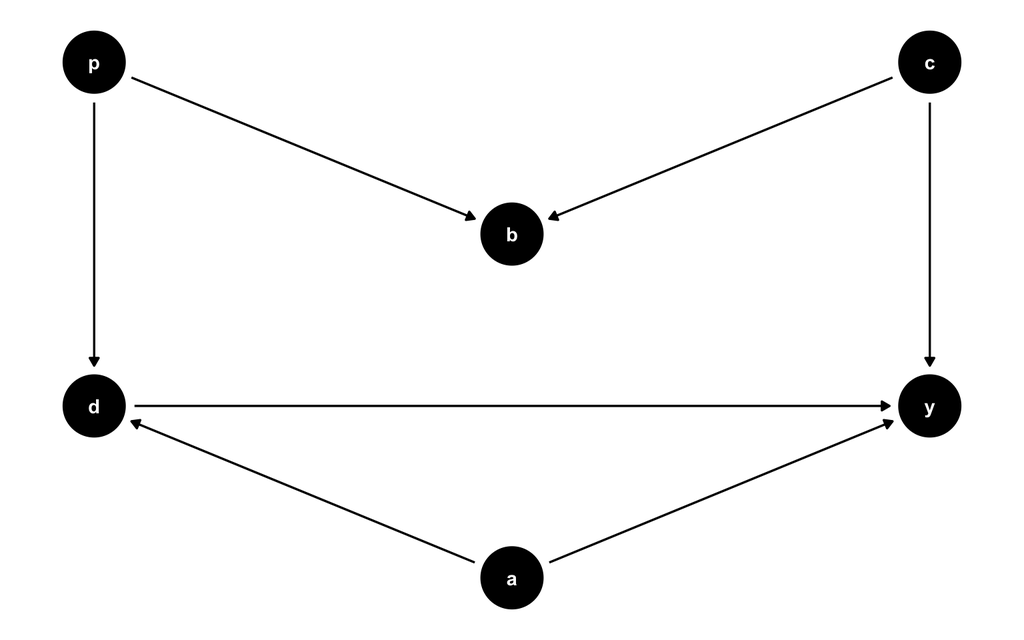

```r
coord_dag <- list(
  x = c(d = 0, p = 0, b = 1, a = 1 , c = 2, y = 2),
  y = c(d = 0, p = 2, b = 1, a = -1, c = 2, y = 0)
)

our_dag <- ggdag::dagify(d ~ p + a, # p and a pointing at d
                         b ~ p + c, # p and c pointing at b
                         y ~ d + a + c, # d, a, and c pointing at y
                         coords = coord_dag, # our coordinates from the list up there
                         exposure = "d", # we declare out exposure variable
                         outcome = "y") # we declare out outcome variable

ggdag::ggdag(our_dag) +
  theme_dag() # equivalent to theme_void()
```

### Learning about our paths and what adjustments we need

As you have seen, when we **dagify** a DAG in **R** a *dagitty* object is created. These objects tell **R** that we are dealing with DAGs.

This is very important because in addition to plotting them, **we can do analyses on the DAG objects**. A package that complements `ggdag` is the `dagitty` package.

Today, we will focus on two functions from the `dagitty` package:

- `dagitty::paths()`: Returns a list with two components: **paths**, which gives the actual paths, and **open**, which shows whether each path is open (d-connected) or closed (d-separated).
- `dagitty::adjustmentSets()`: Lists the sets of covariates that would allow for unbiased estimation of causal effects, **assuming that the causal graph is correct**.

We just need to input our DAG object.

#### Paths

Let’s see how the output of the `dagitty::paths` function looks like:

```r
dagitty::paths(our_dag)
```

```
## $paths
## [1] "d -> y"                "d <- a -> y"           "d <- p -> b <- c -> y"
##
## $open
## [1]  TRUE  TRUE FALSE
```

We see under `$paths` the three paths we declared during the manual exercise from last week:

- d -> y
- d <- a -> y
- d <- p -> b <- c -> y

Additionally, `$open` tells us whether each path is open. In this case, we see that the second path is the only open non-causal path, so we would need to condition on **a** to close it.

We can also use `ggdag` to present the open paths visually with the `ggdag_paths()` function, as such:

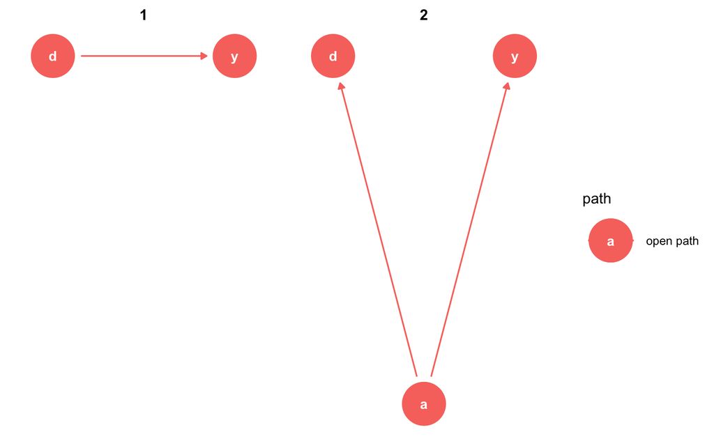

```r
ggdag::ggdag_paths(our_dag) +
  theme_dag()
```

#### Covariate adjustment

In addition to listing all the paths and sorting the backdoors manually, we can use the `dagitty::adjustmentSets()` function.

With this function, we just need to input our DAG object and it will return the different sets of adjustments.

```r
dagitty::adjustmentSets(our_dag)
```

```
## { a }
```

For example, in this DAG there is only one option. We need to control for **a**.

We can also use `ggdag` to present the open paths visually with the `ggdag_adjustment_set()` function, as such:

Also, do not forget to set the argument `shadow = TRUE`, so that the arrows from the adjusted nodes are included.

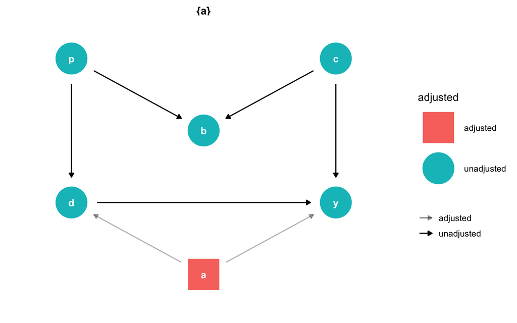

```r
ggdag::ggdag_adjustment_set(our_dag, shadow = T) +
  theme_dag()
```

#### If you want to learn more about DAGs in R

- `ggdag` documentation: https://ggdag.malco.io/
- `dagitty` vignette: https://cran.r-project.org/web/packages/dagitty/dagitty.pdf
- What is `dagitty`: https://cran.r-project.org/web/packages/dagitty/vignettes/dagitty4semusers.html

**NOW LET’S MOVE TO REGRESSION**

## (Re)Introduction to Regression with `lm`

Linear regression is largely used to predict the value of an outcome variable based on one or more input explanatory variables. As we previously discussed, regression addresses a simple mechanical problem, namely, **what is our best guess of y given an observed x**.

- Regression can be utilized without thinking about causes as a *predictive* or *summarizing* tool
- It would not be appropriate to give causal interpretations to any $\beta$, unless we establish the fulfillment of certain assumptions

### Bivariate regression

In bivariate regression, we are modeling a variable $y$ as a mathematical function of one variable $x$. We can generalize this in a mathematical equation as such:

$$y = \beta_{0} + \beta{1}x +
ϵ$$

### Multiple linear regression

In multiple linear regression, we are modeling a variable $y$ as a mathematical function of multiple variables $(x, z, m)$. We can generalize this in a mathematical equation as such:

$$y = \beta_{0} + \beta_{1}x + \beta_{2}z
+ \beta_{3}m + ϵ$$

#### The `lm()` function

This relationship can be formalized mathematically as:

$$Outcome = \beta_0 + \beta_1Explanatory\
Variable + ϵ$$

Our interest here would be to build a model that predicts an outcome variable (**our dependent variable**) using tone or more explanatory variables (**our independent variables**). Fortunately for us, `R` provides us with a very intuitive syntax to model regressions.

**The general syntax for running a regression model in R is the following:**

```r
your_model_biv <- lm(outcome_variable ~ explanarory_variable, data = your_dataset) #for a bivariate regression
your_model_mult <- lm(outcome_variable ~ explanarory_variable_1 + explanarory_variable_2, data = your_dataset) #for multiple regression
```

#### `summary()` and `broom::tidy()`

We have created an object that contains the coefficients, standard errors and further information from your model. To see the estimates, you could use the base R function `summary()`. **This function is very useful when you want to print your results in your console.**

Alternatively, you can use the `tidy()` function from the `broom` package. The function constructs a data frame that summarizes the model’s statistical findings. You can see what else you can do with broom by running: vignette(“broom”). **The `broom::tidy()` function is useful when you want to store the values for future use (e.g., visualizing them)**

```r
summary(your_model)
broom::tidy(your_model)
```

## Matching in `R` with `MatchIt`

> ⚠️ **Note: We use this example for illustrative purposes. It is unlikely that the we retrieve true causal estimates from the matching exercise. As it was explained last week, we would need to assume that the covariates we chose to match on fulfill the adjustment criterion. Still, this is valuable for illustrative purposes**

### Our data

Today we will work with data from the Early Childhood Longitudinal Study (ECLS).

```r
ecls_df <-
  readr::read_csv("https://raw.githubusercontent.com/seramirezruiz/stats-ii-lab/master/Session%204/data/ecls.csv") %>%
  dplyr::select(-childid, -race, -w3daded,
                -w3momed, -w3inccat) #drop these columns (-)

names(ecls_df) #checking the names of the variables in the data frame
```

```
##  [1] "catholic"      "race_white"    "race_black"    "race_hispanic"
##  [5] "race_asian"    "p5numpla"      "p5hmage"       "p5hdage"
##  [9] "w3daded_hsb"   "w3momed_hsb"   "w3momscr"      "w3dadscr"
## [13] "w3income"      "w3povrty"      "p5fstamp"      "c5r2mtsc"
## [17] "c5r2mtsc_std"
```

#### Reference links:

1. `MatchIt`: https://cran.r-project.org/web/packages/MatchIt/vignettes/matchit.pdf
2. `Cobalt`: (optional library for matching plots and extra features): https://cran.r-project.org/web/packages/cobalt/vignettes/cobalt_A0_basic_use.html
3. `kableExtra`: (for formatting tables): https://cran.r-project.org/web/packages/kableExtra/vignettes/awesome_table_in_html.html
4. `modelsummary`: (for formatting model output): https://vincentarelbundock.github.io/modelsummary/articles/modelsummary.html
5. `marginaleffects`: (for computing a wide range of estimands): https://marginaleffects.com/
6. Video overview of matching concepts: https://fr.coursera.org/lecture/crash-course-in-causality/overview-of-matching-JQfPC

### Comparing Differences in Means and Balance Tables

As you may have seen in this week’s application paper, balance tables feature prominently in work that utilizes matching.

In binary treatment setups, **balance tables** present an overview of the difference in means for the groups across covariates.

Let’s take the data set as an example to review how to compare differences in means and build balance tables in **R**. There are multiple ways to explore these kinds of questions. In this lab we will leverage t-tests to check the statistical significance of the difference in means.

In other words, we want to know whether the observed differences in average value of a variable between the two groups or samples can be due to random chance (our null hypothesis).

#### T-tests in R

In this case, let’s imagine we want to check the statistical significance of the differences in the composition of the catholic and public school samples in the `w3povrty` (under the poverty line) variable.

The general syntax for a t-test is simply as follows. The vectors refer to the variables whose mean you want to compare.

```r
t.test(y ~ x, data = your_data)
```

#### Exercise

```r
t.test(w3povrty ~ catholic, data = ecls_df)
```

```
##
##  Welch Two Sample t-test
##
## data:  w3povrty by catholic
## t = 26.495, df = 4034.6, p-value < 2.2e-16
## alternative hypothesis: true difference in means between group 0 and group 1 is not equal to 0
## 95 percent confidence interval:
##  0.1678107 0.1946307
## sample estimates:
## mean in group 0 mean in group 1
##      0.21918633      0.03796562
```

- What does the *group 0* mean tell us?
- What does the *group 1* mean tell us?
- Is the difference between catholic school and public school students statistically significant?

### Balance tables in R

Now let’s take a look at how can we create a simple and good looking balance table. We have provided you a custom function called `balance_table_stats2()`. The syntax is as follows:

```r
balance_table_stats2(data, covariates_for_the_test, treatment_variable, print_kable = TRUE or FALSE)
```

The idea here is to compare the mean values of different variables across populations or groups. In our case, let’s see whether the catholic and public school groups differ across the covariates in the data set:

Here is one way to create the table **(you can adapt this code for the assignment)**.

```r
# create a list with the covariates
list_cov <- c("race_white", "race_black", "race_hispanic", "race_asian", "p5numpla",
              "p5hmage", "p5hdage", "w3daded_hsb", "w3momed_hsb", "w3momscr", "w3dadscr",
              "w3income", "w3povrty", "p5fstamp", "c5r2mtsc", "c5r2mtsc_std")

balance_table_stats2(ecls_df, list_cov, "catholic", print_kable = T)
```

| Variable | Control | Treatment | P value |
| --- | --- | --- | --- |
| race_white | 0.56 | 0.73 | 0.00 |
| race_black | 0.14 | 0.05 | 0.00 |
| race_hispanic | 0.18 | 0.13 | 0.00 |
| race_asian | 0.07 | 0.05 | 0.03 |
| p5numpla | 1.13 | 1.09 | 0.00 |
| p5hmage | 37.56 | 39.58 | 0.00 |
| p5hdage | 40.39 | 41.99 | 0.00 |
| w3daded_hsb | 0.49 | 0.26 | 0.00 |
| w3momed_hsb | 0.46 | 0.23 | 0.00 |
| w3momscr | 43.11 | 47.49 | 0.00 |
| w3dadscr | 42.71 | 46.36 | 0.00 |
| w3income | 54889.16 | 82074.30 | 0.00 |
| w3povrty | 0.22 | 0.04 | 0.00 |
| p5fstamp | 0.13 | 0.02 | 0.00 |
| c5r2mtsc | 50.21 | 52.39 | 0.00 |
| c5r2mtsc_std | -0.03 | 0.19 | 0.00 |

#### Exercise

- Are the differences in means significant at conventional levels?
- What differences strike you from the composition of the two samples?

### The Effect of attending private catholic school on student achievement

> In this tutorial, we’ll analyze the effect of going to Catholic school, as opposed to public school, on student achievement. Because students who attend Catholic school on average are different from students who attend public school, we will use matching to get more credible causal estimates of Catholic schooling.

### Exploration of the data

```r
ecls_df %>%
  dplyr::group_by(catholic) %>%
  dplyr::summarize(n_students = n(),
                   avg_math = mean(c5r2mtsc_std),
                   std_error = sd(c5r2mtsc_std) / sqrt(n_students)) %>%
  round(3) %>% # round the results
  knitr::kable() %>% # create kable table
  kableExtra::kable_styling() # view kable table
```

| catholic | n_students | avg_math | std_error |
| --- | --- | --- | --- |
| 0 | 9568 | -0.031 | 0.010 |
| 1 | 1510 | 0.194 | 0.022 |

We can see that we have many more students that did not attend Catholic school than those who did. Also, the Catholic school students have a higher average math score.

### Naive Average Treatment Effect (NATE)

We can naively compare the students on their standardized math scores (c5r2mtsc_std). As you remember, the Naive Average Treatment Effect (NATE) is the difference in the means of the observed outcomes of the two groups:

$$NATE = E(y^1 | D = 1) - E(y^0 | D =
0)$$

In this case, the NATE would be difference between the average math scores.

#### NATE manually

Do you remember what we did in the last section?

We could subtract the `avg_math` for the *catholic = 1* and the `avg_math` for the *catholic = 0*

$$NATE = 0.194 - (-0.031)$$
$$NATE = 0.194 + 0.031 = 0.225$$

#### NATE with `t.test()`

```r
t.test(c5r2mtsc_std ~ catholic, data = ecls_df)
```

```
##
##  Welch Two Sample t-test
##
## data:  c5r2mtsc_std by catholic
## t = -9.1069, df = 2214.5, p-value < 2.2e-16
## alternative hypothesis: true difference in means between group 0 and group 1 is not equal to 0
## 95 percent confidence interval:
##  -0.2727988 -0.1761292
## sample estimates:
## mean in group 0 mean in group 1
##     -0.03059583      0.19386817
```

#### NATE with `lm()`

```r
lm(c5r2mtsc_std ~ catholic, data = ecls_df) %>%
  modelsummary::modelsummary(stars = c('*' = .1, '**' = .05, '***' = .01),
                             statistic = 'conf.int',
                             fmt = 2)
```

|  | (1) |
| --- | --- |
| (Intercept) | -0.03*** |
|  | [-0.05, -0.01] |
| catholic | 0.22*** |
|  | [0.17, 0.28] |
| Num.Obs. | 11078 |
| R2 | 0.006 |
| R2 Adj. | 0.006 |
| AIC | 31377.1 |
| BIC | 31399.0 |
| Log.Lik. | -15685.545 |
| RMSE | 1.00 |

* p < 0.1, ** p < 0.05, *** p < 0.01

#### Exercise

- What parallels do you find between subtracting the manually extracted means, the t-test, and the linear regression?

### Matching with `MatchIt`

`MatchIt` is designed for causal inference with a dichotomous treatment variable and a set of pre-treatment control variables. Any number or type of dependent variables can be used.

We have five steps:

- Consider the type of effect and target population you will analyze
- Select the set of covariates satisfying the adjustment criterion
- Perform the match with `MatchIt::matchit()`
- Create a new data frame with the matched data with `MatchIt::match.data()` or `MatchIt::get_matches()`
- Model

The basic syntax is as follows:

```r
match_process <- MatchIt::matchit(treatment ~ x1 + x2, data = mydata) # NOTE. We include treatment ~ covariates
matched_df <- MatchIt::get_matches(match_process) #when matching with replacement
matched_df <- MatchIt::match.data(match_process) #for other cases
matched_model <- lm(outcome ~ trearment * (x1 + x2), weights = weights, data = matched_df)
```

where treat is the dichotomous treatment variable, and x1 and x2 are pre-treatment covariates, all of which are contained in the data frame *mydata*.

> ⚠️ **IMPORTANT: As you can see, the outcome variable should not be included in the matching procedure.**

`MatchIt` is capable of using several matching *methods*:

- Exact (*method = “exact”*): The simplest version of matching is exact. This technique matches each treated unit to all possible control units with exactly the same values on all the covariates, forming subclasses such that within each subclass all units (treatment and control) have the same covariate values.
- Subclassification (*method = “subclass”*): When there are many covariates (or some covariates can take a large number of values), finding sufficient exact matches will often be impossible. The goal of subclassification is to form subclasses, such that in each of them the distribution (rather than the exact values) of covariates for the treated and control groups are as similar as possible.
- Nearest Neighbor (*method = “nearest”*): Nearest neighbor matching selects the best control matches for each individual in the treatment group. Matching is done using a distance measure (propensity score) specified by the distance option (default = logit).
- As well as optimal matching, full matching, genetic matching, and coarsened exact matching, all of which are detailed in the documentation.

A few additional arguments are important to know about:

- *distance*: this refers to propensity scores. There are many options for how to calculate these within MatchIt.
- *discard*: specifies whether to discard units that fall outside some measure of support of the distance measure (default is “none”, discard no units). For example, if some treated units have extremely high propensity scores that are higher than any control units, we could drop those.
- *replace*: a logical value indicating whether each control unit can be matched to more than one treated unit (default is *replace = FALSE*, each control unit is used at most once).
- *ratio*: the number of control units to match to each treated unit (default is *ratio = 1*).
- There are also some optional arguments for most of the matching methods, which you can read about in the documentation if you are interested.

### Exact Matching

We can use a combination of the results from our balance table and theory to identify which variables to use for matching.

**For illustration purposes, let’s perform an exact match with (and assume this specification fulfills the adjustment criterion)**:

- race_white: Is the student white (1) or not (0)?
- p5hmage: Mother’s age
- w3income: Family income
- p5numpla: Number of places the student has lived for at least 4 months
- w3momed_hsb: Is the mother’s education level high-school or below (1) or some college or more (0)?

```r
# first we must omit missing values (MatchIt does not allow missings)
match_data <- ecls_df %>%
  dplyr::select(catholic, c5r2mtsc_std, race_white, p5hmage,
                w3income, p5numpla, w3momed_hsb) %>%
  na.omit()

str(match_data) #Let's see how many observations we have
```

```
## tibble [9,267 × 7] (S3: tbl_df/tbl/data.frame)
##  $ catholic    : num [1:9267] 0 0 0 1 0 0 0 0 0 0 ...
##  $ c5r2mtsc_std: num [1:9267] 0.982 0.594 0.491 1.451 2.596 ...
##  $ race_white  : num [1:9267] 1 1 1 1 1 1 1 0 1 1 ...
##  $ p5hmage     : num [1:9267] 47 41 43 38 47 30 41 38 28 31 ...
##  $ w3income    : num [1:9267] 62500 45000 62500 87500 150000 ...
##  $ p5numpla    : num [1:9267] 1 1 1 1 1 1 1 1 1 1 ...
##  $ w3momed_hsb : num [1:9267] 0 0 0 0 0 0 0 1 1 1 ...
##  - attr(*, "na.action")= 'omit' Named int [1:1811] 3 20 22 27 33 36 45 48 52 55 ...
##   ..- attr(*, "names")= chr [1:1811] "3" "20" "22" "27" ...
```

```r
# perform exact match
exact_match <- MatchIt::matchit(catholic ~ race_white + p5hmage + w3income +
                                  p5numpla + w3momed_hsb,
                                method = "exact",
                                data = match_data)

# Try seeing the output in the console with summary(exact_match)

# grab the matched data into a new data frame
data_exact_match <- MatchIt::match.data(exact_match)
```

At this point, we have successfully performed the match. The maintainers of the `MatchIt` package recommend:

> After full matching and most other matching methods, we can run a regression of the outcome on the treatment and covariates in the matched sample (i.e., including the matching weights) and estimate the treatment effect using g-computation as implemented in marginaleffects::comparisons(). Finally, we use marginaleffects::avg_comparisons() to perform g-computation to estimate the ATT. We recommend using cluster-robust standard errors for most analyses, with pair membership as the clustering variable; avg_comparisons() makes this straightforward.

Here is an example of how we would do this:

```r
# estimate effect again with new data frame
exact_match_model <- lm(c5r2mtsc_std ~ catholic * (race_white + p5hmage + w3income +
                                                     p5numpla + w3momed_hsb), weights = weights, data = data_exact_match)


marginaleffects::avg_comparisons(exact_match_model,
                                 variables = "catholic",
                                 vcov = ~subclass,
                                 newdata = subset(data_exact_match, catholic == 1),
                                 wts = "weights")
```

```
##
##  Estimate Std. Error     z Pr(>|z|)    S  2.5 % 97.5 %
##    -0.177     0.0286 -6.19   <0.001 30.6 -0.233 -0.121
##
## Term: catholic
## Type:  response
## Comparison: 1 - 0
## Columns: term, contrast, estimate, std.error, statistic, p.value, s.value, conf.low, conf.high, predicted_lo, predicted_hi, predicted
```

> ⚠️ **Note. The outcome model coefficients and tests should not be interpreted or reported.** See `vignette("estimating-effects")` for more information on how to estimate effects and standard errors with different forms of matching and with different outcome types.

### Propensity Scores

If we want to perform non-exact matching, we can use **propensity scores**. We can generate these manually using a logit model on the unmatched data set.

When we extract **propensity scores**, we model the propensity of each unit of falling under the treatment group based on their values on a set of covariates. This is how we would do this manually:

```r
# create a new column with income by the thousands for more interpretable output
ecls_df <- ecls_df %>%
  dplyr::mutate(w3income_1k = w3income / 1000)

# estimate logit model
m_ps <- glm(catholic ~ race_white + w3income_1k +
              p5hmage + p5numpla + w3momed_hsb,
            family = binomial(link = "logit"), # you can also use a probit link here
            data = ecls_df)

# extract predicted probabilities
# type = "response" option tells R to output probabilities of the form P(Y = 1|X)
prs_df <- dplyr::tibble(pr_score = predict(m_ps, type = "response"),
                        catholic = m_ps$model$catholic) # the actual values
```

Let’s plot the propensity scores by treatment group to explore common support:

#### Counts

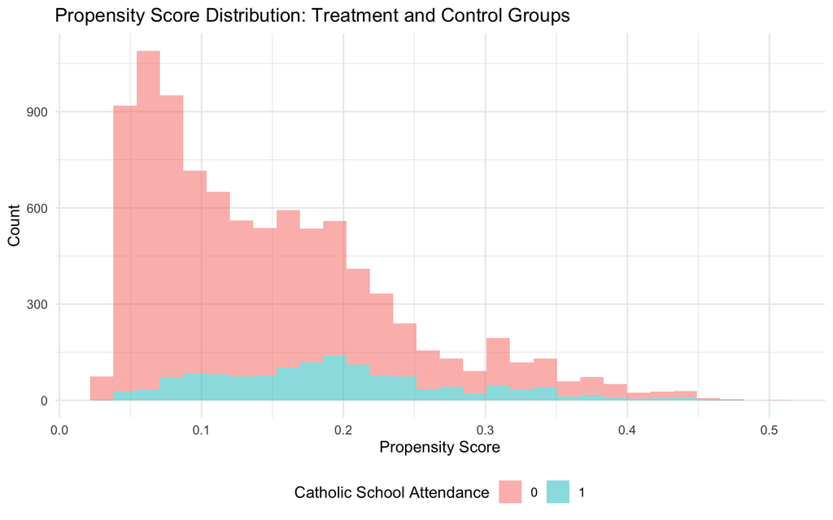

```r
# Histogram
ggplot(prs_df, aes(x = pr_score, fill = factor(catholic))) +
  geom_histogram(alpha = 0.5) +
  theme_minimal() +
  theme(legend.position = "bottom") +
  labs(title = "Propensity Score Distribution: Treatment and Control Groups",
       x = "Propensity Score",
       y = "Count",
       fill = "Catholic School Attendance")
```

#### Density

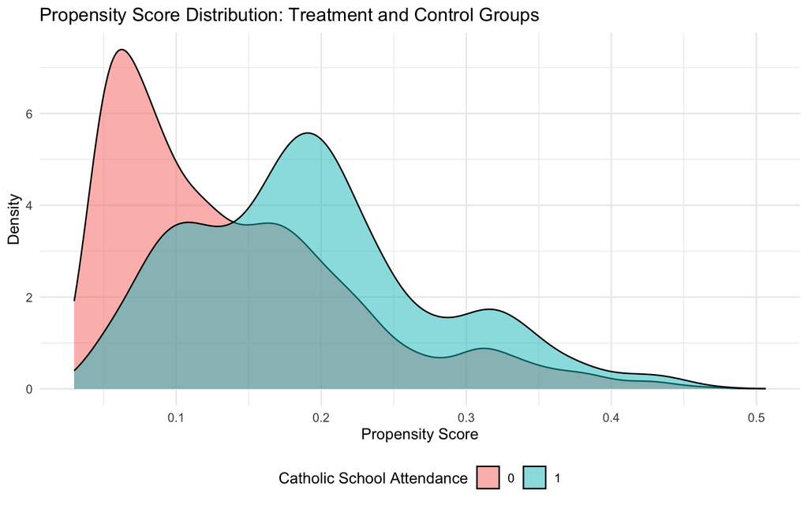

```r
# Density plot
ggplot(prs_df, aes(x = pr_score, fill = factor(catholic))) +
  geom_density(alpha = 0.5) +
  theme_minimal() +
  theme(legend.position = "bottom") +
  labs(title = "Propensity Score Distribution: Treatment and Control Groups",
       x = "Propensity Score",
       y = "Density",
       fill = "Catholic School Attendance")
```

#### Raw data points

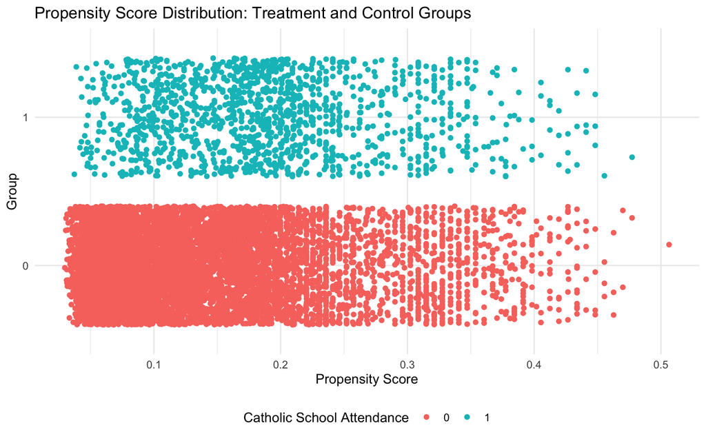

```r
# Jittered point plot
ggplot(prs_df, aes(x = pr_score, y = factor(catholic), color = factor(catholic))) +
  geom_jitter() +
  theme_minimal() +
  theme(legend.position = "bottom") +
  labs(title = "Propensity Score Distribution: Treatment and Control Groups",
       x = "Propensity Score",
       y = "Group",
       color = "Catholic School Attendance")
```

#### Exercise

- What do these plots tell us?

### Non-Exact Matching

`MatchIt` can generate propensity scores itself, so we don’t need to manually go through the process above. Let’s try putting together a non-exact matching formula yourself! Try:

- nearest neighbor matching
- with replacement
- with a one-to-one ratio
- on the *match_data* data set

```r
one_match <- MatchIt::matchit(catholic ~ race_white + w3income + p5hmage +
                                p5numpla + w3momed_hsb,
                              method = "nearest",
                              ratio = 1,
                              replace = TRUE,
                              data = match_data)

summary(one_match)
```

```
##
## Call:
## MatchIt::matchit(formula = catholic ~ race_white + w3income +
##     p5hmage + p5numpla + w3momed_hsb, data = match_data, method = "nearest",
##     replace = TRUE, ratio = 1)
##
## Summary of Balance for All Data:
##             Means Treated Means Control Std. Mean Diff. Var. Ratio eCDF Mean
## distance           0.1927        0.1379          0.6486     1.0007    0.2086
## race_white         0.7411        0.5914          0.3418          .    0.1497
## w3income       82568.9357    55485.0210          0.5777     1.1373    0.1565
## p5hmage           39.5932       37.5658          0.3874     0.6383    0.0408
## p5numpla           1.0917        1.1298         -0.1242     0.6132    0.0076
## w3momed_hsb        0.2234        0.4609         -0.5703          .    0.2375
##             eCDF Max
## distance      0.3109
## race_white    0.1497
## w3income      0.3062
## p5hmage       0.1893
## p5numpla      0.0277
## w3momed_hsb   0.2375
##
## Summary of Balance for Matched Data:
##             Means Treated Means Control Std. Mean Diff. Var. Ratio eCDF Mean
## distance           0.1927        0.1927          0.0000     0.9997    0.0000
## race_white         0.7411        0.7493         -0.0186          .    0.0081
## w3income       82568.9357    81775.6653          0.0169     1.0096    0.0036
## p5hmage           39.5932       39.6169         -0.0045     1.0224    0.0015
## p5numpla           1.0917        1.0777          0.0459     1.1631    0.0031
## w3momed_hsb        0.2234        0.2226          0.0018          .    0.0007
##             eCDF Max Std. Pair Dist.
## distance      0.0030          0.0001
## race_white    0.0081          0.0625
## w3income      0.0081          0.0396
## p5hmage       0.0074          0.1131
## p5numpla      0.0126          0.0846
## w3momed_hsb   0.0007          0.0586
##
## Sample Sizes:
##               Control Treated
## All           7915.      1352
## Matched (ESS)  994.51    1352
## Matched       1149.      1352
## Unmatched     6766.         0
## Discarded        0.         0
```

Now, let’s plot the propensity scores for the treated and untreated units.

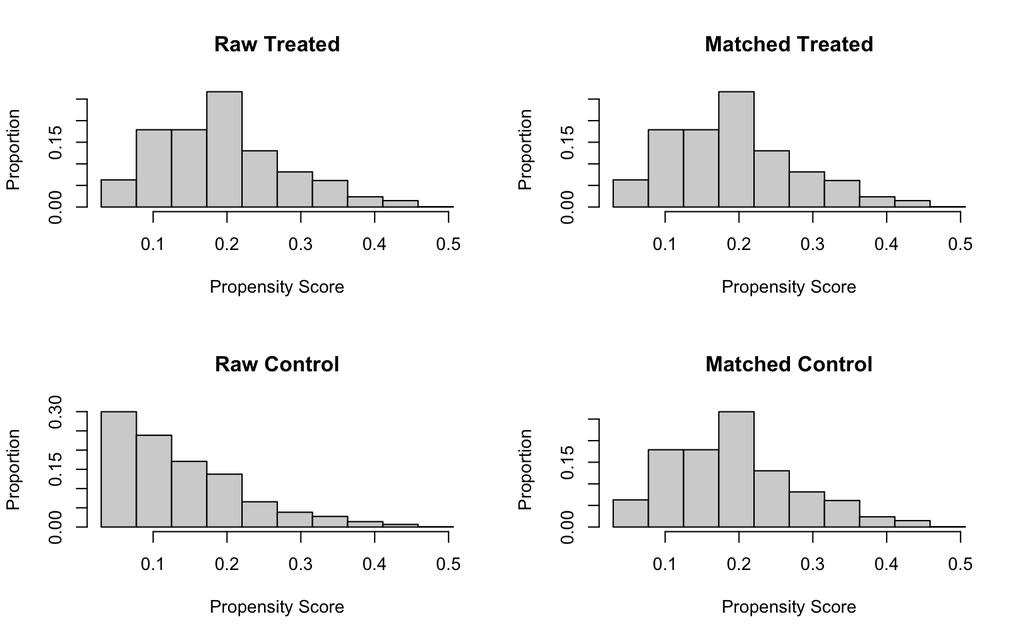

```r
# simple plot - check out the cobalt package for nicer options, or use ggplot2 to create your own!
plot(one_match, type = "hist")
```

Let’s extract the data from *one_match* and creating a balance table like the one we did before, just this time using the new data. Scroll down for the answer when you’re ready.

```r
# grab data set
data_prop_match <- MatchIt::get_matches(one_match) #NOTE. the get_matches

# create list of covariates for the table
list_cov_match <- c("race_white", "p5hmage", "w3income", "p5numpla", "w3momed_hsb")

balance_table_stats2(data_prop_match, list_cov_match, "catholic", print_kable = TRUE)
```

| Variable | Control | Treatment | P value |
| --- | --- | --- | --- |
| race_white | 0.75 | 0.74 | 0.63 |
| p5hmage | 39.62 | 39.59 | 0.91 |
| w3income | 81775.67 | 82568.94 | 0.66 |
| p5numpla | 1.08 | 1.09 | 0.22 |
| w3momed_hsb | 0.22 | 0.22 | 0.96 |

Those means look very close. However, have you seen how many units we failed to match? What do you think about that?

Finally, let’s estimate on the matched data set:

```r
prop_match_model <- lm(c5r2mtsc_std ~ catholic * (race_white + w3income + p5hmage +
                                                    p5numpla + w3momed_hsb), weights = weights, data = data_prop_match)

marginaleffects::avg_comparisons(prop_match_model,
                                 variables = "catholic",
                                 vcov = ~subclass,
                                 newdata = subset(data_prop_match, catholic == 1),
                                 wts = "weights")
```

```
##
##  Estimate Std. Error     z Pr(>|z|)    S  2.5 % 97.5 %
##    -0.166     0.0337 -4.93   <0.001 20.2 -0.232   -0.1
##
## Term: catholic
## Type:  response
## Comparison: 1 - 0
## Columns: term, contrast, estimate, std.error, statistic, p.value, s.value, conf.low, conf.high, predicted_lo, predicted_hi, predicted
```

#### What do these results tell us?

### Let’s do it one last time with full matching

Now let’s try the followin specification:

- full matching
- `distance = "glm"`
- `link = "probit"`
- on the *match_data* data set

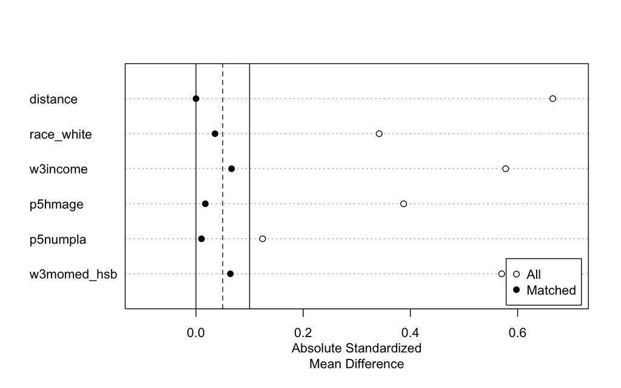

```r
full_match <- MatchIt::matchit(catholic ~ race_white + w3income + p5hmage +
                                 p5numpla + w3momed_hsb,
                               method = "full",
                               distance = "glm",
                               link = "probit",
                               data = match_data)


# simple plot - check out the cobalt package for nicer options, or use ggplot2 to create your own!
plot(summary(full_match), xlim=c(-0.1, 0.7))
```

Let’s extract the data from *full_match*.

```r
full_match # let's get an overview of what we did
```

```
## A `matchit` object
##  - method: Optimal full matching
##  - distance: Propensity score
##              - estimated with probit regression
##  - number of obs.: 9267 (original), 9267 (matched)
##  - target estimand: ATT
##  - covariates: race_white, w3income, p5hmage, p5numpla, w3momed_hsb
```

```r
# grab data set
data_full_match <- MatchIt::match.data(full_match)

# model
full_match_model <- lm(c5r2mtsc_std ~ catholic * (race_white + w3income + p5hmage +
                                                    p5numpla + w3momed_hsb),
                       weights = weights,
                       data = data_full_match)

# get "ATT"
marginaleffects::avg_comparisons(full_match_model,
                                 variables = "catholic",
                                 vcov = ~subclass,
                                 newdata = subset(data_full_match, catholic == 1),
                                 wts = "weights")
```

```
##
##  Estimate Std. Error     z Pr(>|z|)   S  2.5 % 97.5 %
##   -0.0886     0.0309 -2.87  0.00415 7.9 -0.149 -0.028
##
## Term: catholic
## Type:  response
## Comparison: 1 - 0
## Columns: term, contrast, estimate, std.error, statistic, p.value, s.value, conf.low, conf.high, predicted_lo, predicted_hi, predicted
```

As with the exact matching, we can see that those that did not attend Catholic school performed better on the test than those who did. The estimated effect of attending private school is a reduction of about **0.089 standard deviations**.

#### Reporting out results

The maintainers of the package recommend the following when reporting matching results in a manuscript or research report:

> One should be as detailed as possible about the matching procedure and the decisions made to ensure the analysis is replicable and can be adequately assessed for soundness by the audience. Key pieces of information to include are 1) **the matching specification used** (including the method and any additional options, like calipers or common support restrictions), 2) **the distance measure** used (including how it was estimated e.g., using logistic regression for propensity scores), 3) **which other matching methods were tried prior to settling on a final specification and how the choices were made**, 4) **the balance of the final matching specification** (including standardized mean differences and other balance statistics for the variables, their powers, and their interactions; some of these can be reported as summaries rather than in full detail), 5) **the number of matched, unmatched, and discarded units** included in the effect estimation, and 6) t**he method of estimating the treatment effect and standard error or confidence interval** (including the specific model used and the specific type of standard error). See Thoemmes and Kim (2011) for a complete list of specific details to report. Below is an example of how we might write up the prior analysis:

#### This would be a rough draft of that:

To estimate the treatment effect and its standard error, we fit a linear regression model with the standardized match score as the outcome and the treatment, covariates, and their interaction as predictors and included the full matching weights in the estimation. The `lm()` function was used to fit the outcome, and the `comparisons()` function in the `marginaleffects` package was used to perform g-computation in the matched sample to estimate the ATT. A cluster-robust variance was used to estimate its standard error with matching stratum membership as the clustering variable.

# **Acknowledgements**

This tutorial is inspired by Simon Ejdemyr’s [tutorial](https://sejdemyr.github.io/r-tutorials/statistics/tutorial8.html).

This script was drafted by [Lisa Oswald](https://lfoswald.github.io/) and [Sebastian Ramirez-Ruiz](https://seramirezruiz.github.io/), with contributions by [Adelaida Barrera Daza](https://www.linkedin.com/in/adelaidabarrera/), [Carolina Díaz Suárez](https://www.linkedin.com/in/carolinadiazsuarez/), [Sofía García-Durrer](https://www.linkedin.com/in/sofia-garcia-durrer/), and [William Fernandez](https://www.hertie-school.org/en/who-we-are/profile/person/tinoco).